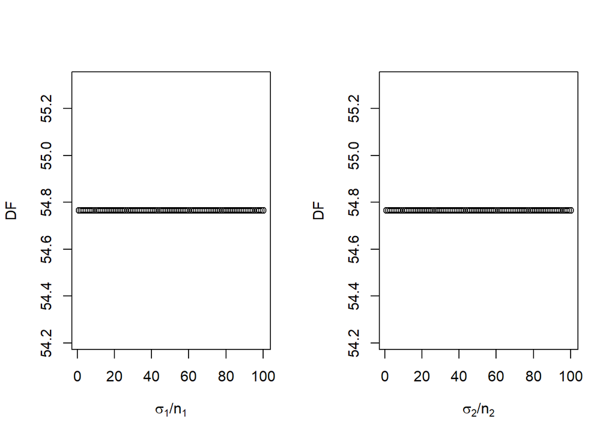

Degrees of freedom (DF) when computing the bias of Shieh’s $d_s$, when variances and sample sizes are unequal across groups, as a function of the variances and sample sizes ratios ($\frac{\sigma_j}{n_j}$)

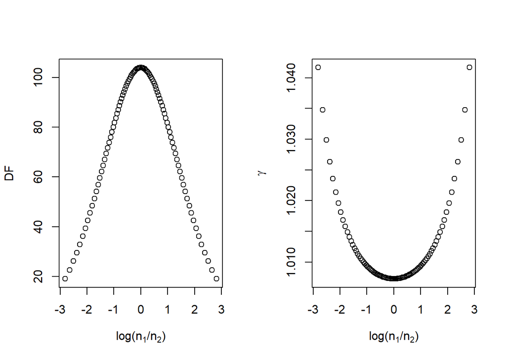

Degrees of freedom (DF) and $\gamma$, when computing the bias of Shieh’s $d_s$, when variances and sample sizes are unequal across groups and $\frac{\sigma^2_1}{n_1}=\frac{\sigma^2_2}{n_2}$, as a function of the logarithm of the sample sizes ratio ($log \left( \frac{n_1}{n_2} \right)$)

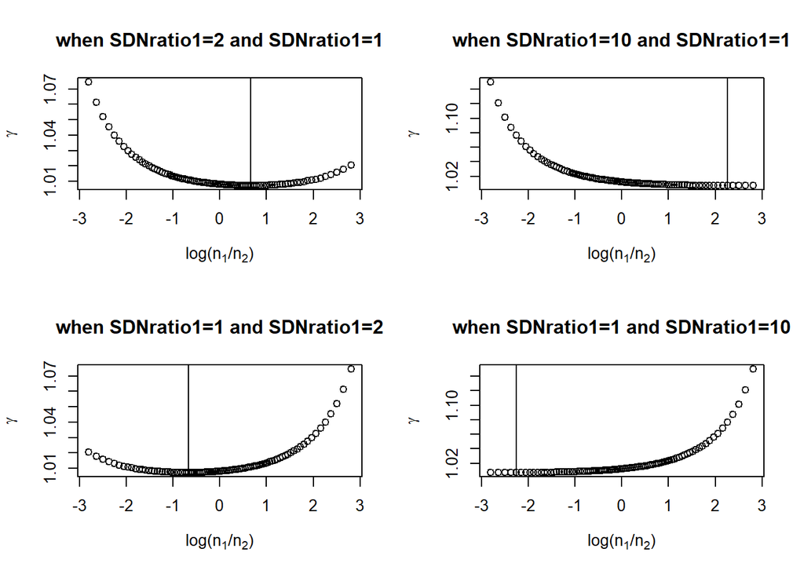

- The variances and sample sizes ratios don’t matter per se (see Figure ). However, the pairing between these ratios and sample sizes has an effect on the bias:
  - When $\frac{\sigma^2_1}{n_1}=\frac{\sigma^2_2}{n_2}$, the smallest bias occurs when sample sizes are equal across groups. The further the sample sizes ratio is from 1, the larger the bias (see Figure ).
  - When $\frac{\sigma^2_1}{n_1} \neq \frac{\sigma^2_2}{n_2}$, the minimum bias will always occure when $min(\frac{\sigma^2_j}{n_j})$ will be associated with $min(n_j)$. In other word, when $\frac{\sigma^2_1}{n_1}>\frac{\sigma^2_2}{n_2}$, the sample sizes ratio associated with the minimum bias will be positive, meaning that $n_1>n_2$ (and the larger the difference between $\frac{\sigma^2_1}{n_1}$ and $\frac{\sigma^2_2}{n_2}$, the further from 1 will be this sample sizes ratio; see the two top plots in Figure ). On the other side, when $\frac{\sigma^2_1}{n_1}<\frac{\sigma^2_2}{n_2}$, the sample sizes ratio associated with the minimum bias will be negative, meaning that $n_1<n_2$ (and the larger the difference between $\frac{\sigma^2_1}{n_1}$ and $\frac{\sigma^2_2}{n_2}$, the further from 1 will be this sample sizes ratio; see the two bottom plots in Figure ).